# [Введение в анализ данных](https://thetahat.ru/courses/ad)

## Домашнее задание 5. Компьютерное зрение & генеративные модели

**Правила, прочитайте внимательно:**

- Выполненную работу нужно отправить телеграм-боту `@thetahat_ds25_bot`. Для начала работы с ботом каждый раз отправляйте `/start`. Дождитесь подтверждения от бота, что он принял файл. Если подтверждения нет, то что-то не так. **Работы, присланные иным способом, не принимаются.**
- Дедлайн см. в боте. После дедлайна работы не принимаются кроме случаев наличия уважительной причины.
- Прислать нужно **ноутбук в формате `ipynb`**. Если вы строите интерактивные графики, их стоит прислать в формате html.
- Следите за размером файлов. **Бот не может принимать файлы весом более 20 Мб.** Если файл получается больше, заранее разделите его на несколько.
- Выполнять задание необходимо полностью самостоятельно. **При обнаружении списывания всем участникам списывания дается штраф -2 балла к итоговой оценке за семестр.**
- Решения, размещенные на каких-либо интернет-ресурсах, не принимаются. Кроме того, публикация решения в открытом доступе может быть приравнена к предоставлении возможности списать.
- Обратите внимание на [**правила использования ИИ-инструментов**](https://thetahat.ru/courses/ai-rules) при решении домашнего задания.
- **Код из рассказанных на занятиях ноутбуков** можно использовать без ограничений.
- Для выполнения задания используйте этот ноутбук в качестве основы, ничего не удаляя из него. Можно добавлять необходимое количество ячеек.
- Комментарии к решению пишите в markdown-ячейках.
- Выполнение задания (ход решения, выводы и пр.) должно быть осуществлено на русском языке.
- Решение проверяется системой ИИ-проверки

[figure not shown]

  **ThetaGrader**. Результат проверки валидируется и исправляется человеком, после чего комментарии отправляются студентам.
- Если код будет не понятен проверяющему, оценка может быть снижена.
- Никакой код из данного задания при проверке запускаться не будет. *Если код студента не выполнен, недописан и т.д., то он не оценивается.*
- **Код из рассказанных на занятиях ноутбуков** можно использовать без ограничений.

**Важно!!! Правила заполнения ноутбука:**

- Запрещается удалять имеющиеся в ноутбуке ячейки, менять местами положения задач.
- Сохраняйте естественный линейный порядок повествования в ноутбуке сверху-вниз.
- Отвечайте на вопросы, а также добавляйте новые ячейки в предложенных местах, которые обозначены `<...>`.
- В markdown-ячейка, содержащих описание задачи, находятся специальные отметки, которые **запрещается модифицировать**.
- При нарушении данных правил работа может получить 0 баллов.

**Баллы за задание:**

- Задача 1 — 120 баллов
- Задача 2 — 80 баллов
- Задача 3 — 30 баллов

Баллы учитываются в **факультативной части** курса и не влияют на оценку по основной части.

```python
# Bot check

# HW_ID: fpmi_ad5
# Бот проверит этот ID и предупредит, если случайно сдать что-то не то.

# Status: not final
# Перед отправкой в финальном решении удали "not" в строчке выше.
# Так бот проверит, что ты отправляешь финальную версию, а не промежуточную.
# Никакие значения в этой ячейке не влияют на факт сдачи работы.
```

```python
# При необходимости установите библиотеки, например, раскомментируйте строку ниже
# !pip install torchinfo
```

```python
import warnings
from typing import Union
import seaborn as sns
import torch
import torch.optim as optim
import torchvision
from torchvision import transforms
import torch.nn as nn
import torch.nn.functional as F
import matplotlib.pyplot as plt
import numpy as np


sns.set(font_scale=1, style="darkgrid", palette="Set2")
warnings.simplefilter("ignore")

device = "cuda" if torch.cuda.is_available() else "cpu"
```

Перед выполнением задания обязательно посмотрите [презентацию](https://thetahat.ru/files/ad/main/5/lec5.pdf) и [ноутбук](https://thetahat.ru/files/ad/main/5/cv_classification) про сверточные сети и классификацию, а так же [презентацию](https://thetahat.ru/files/ad/main/5/lec5_2.pdf) и [ноутбук](https://thetahat.ru/files/ad/main/5/cv_complex_examples) про перенос стиля и генеративные сети.

❗ **Весь код работы с библиотекой PyTorch необходимо написать самостоятельно, без использования ИИ-инструментов.** Но можно использовать код из ноутбуков, рассказанных на занятии. Можно использовать ИИ-инструменты для написания технического кода (например, построение графиков), оформления ранее написанного кода и в качестве справки. Выводы необходимо делать самостоятельно.

### Задача 1. Классификация MNIST

В данной задаче вам нужно провести сравнительный анализ сверточных нейросетей с различными параметрами на датасета рукописных цифр MNIST. С этим датасетом вы уже познакомились в [предыдущем задании](https://thetahat.ru/courses/ad/main/4/ad_task4_part1). Классификация в MNIST значительно проще, чем в CIFAR, рассмотренном на [занятии](https://thetahat.ru/files/ad/main/5/cv_classification), поэтому ваша задача — достичь **на валидации** хотя бы одной из моделей точности 97%. Вы можете свободно использовать код с занятия.

> Использования слоев с семинара (свертка, pooling) более чем достаточно для достижения 97% точности на тесте. Также не делайте сеть глубокой.

> Тестируйте работоспособность кода на CPU с небольшим количеством итераций. Если все работает, и хочется ускорить процесс, переходите на GPU.

Следуйте указаниям ниже.

Загрузим датаcет из `torchvision.datasets`.

```python
# Данные для обучения
train_dataset = torchvision.datasets.MNIST(
    root="./data", train=True, download=True, transform=transforms.ToTensor()
)
# Данные для тестирования
val_dataset = torchvision.datasets.MNIST(
    root="./data", train=False, download=True, transform=transforms.ToTensor()
)
# Классы объектов в датасете
num_classes = 10
classes_list = [str(i) for i in range(num_classes)]
```

Визуализируйте несколько картинок с соответствующими метками из датасета.

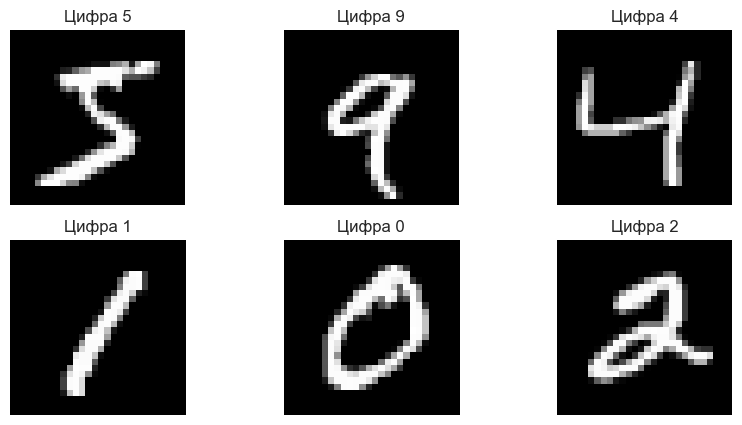

```python
fig, ax = plt.subplots(nrows=2, ncols=3, figsize=(10, 5))
# ax.flatten()
for i in range(6):
    ax[i % 2, i % 3].imshow(train_dataset.data[i], cmap="gray")
    ax[i % 2, i % 3].set_title(f'Цифра {int(train_dataset.targets[i])}')
    ax[i % 2, i % 3].axis('off')
```

Создайте генераторы батчей.

```python
from torch.utils.data import DataLoader

mnist_dataloader = DataLoader(train_dataset, batch_size=1024, shuffle=True)
```

**Эксперимент 1.** Создайте хотя бы 5 сверточных нейросетей с разным количеством линейных и сверточных слоев. Должен присутствовать хотя бы 1 сверточный слой и хотя бы 1 линейный слой. Для каждой посмотрите количество параметров с помощью `torchinfo.summary`.

```python
class simple_cnn(nn.Module):
    def __init__(self, input_channels: int = 1, num_conv_layers: int = 1, num_lin_layers: int = 1,
                 num_filters: int = 16, kernel_size: int = 3, padding: int = 1,
                 num_classes: int = 10, input_size: int = 28):
        super(simple_cnn, self).__init__()
        self.history = []
        conv_layers = []
        in_channels = input_channels
        for i in range(num_conv_layers):
            conv_layers.append(
                nn.Conv2d(in_channels=in_channels, out_channels=num_filters, kernel_size=kernel_size, padding=padding)
            )
            conv_layers.append(nn.ReLU())
            in_channels = num_filters
        self.conv_layers = nn.Sequential(*conv_layers)

        self.pool = nn.MaxPool2d(2, 2)

        with torch.no_grad():
            dummy_input = torch.zeros(1, input_channels, input_size, input_size)
            conv_out = self.conv_layers(dummy_input)
            pooled_out = self.pool(conv_out)
            self.flattened_size = pooled_out.view(1, -1).size(1)
        lin_layers = []
        in_features = self.flattened_size
        hidden_size = 50
        for i in range(num_lin_layers):
            out_features = hidden_size if i < num_lin_layers - 1 else num_classes
            lin_layers.append(nn.Linear(in_features, out_features))
            if i < num_lin_layers - 1:
                lin_layers.append(nn.ReLU())
            in_features = out_features
        self.lin_layers = nn.Sequential(*lin_layers)

    def forward(self, x):
        x = self.conv_layers(x)
        x = self.pool(x)
        x = torch.flatten(x, start_dim=1)
        x = self.lin_layers(x)
        return x


    def predict(self, X):
        logits = self.forward(X)
        probabilities = F.softmax(logits, dim=1)
        return torch.argmax(probabilities, dim=1)
```

Обучите сети, используя функцию потерь `nn.CrossEntropyLoss` и оптимизатор `torch.optim.SGD` с дефолтными параметрами.

```python
import torch
import torch.nn as nn


class Net(nn.Module):
    def __init__(self, hidden_size, count_of_classes=10):
        super(Net, self).__init__()

        self.conv1 = nn.Conv2d(1, 16, kernel_size=3, padding=1)
        self.pool = nn.MaxPool2d(2, 2)
        self.fc1 = nn.Linear(16 * 14 * 14, hidden_size)
        self.fc2 = nn.Linear(hidden_size, count_of_classes)
        self.history = []

    def forward(self, x):
        x = self.conv1(x)
        x = nn.functional.relu(x)
        x = self.pool(x)
        x = x.view(x.size(0), -1)
        x = self.fc1(x)
        x = nn.functional.relu(x)
        x = self.fc2(x)
        return x


def train_model(model, device, train_loader, criterion, optimizer, epochs):
    model = model.to(device)
    for epoch in range(epochs):
        for image, label in train_loader:
            image = image.to(device)
            label = label.to(device)
            optimizer.zero_grad()
            output = model(image)
            loss = criterion(output, label)
            loss.backward()
            optimizer.step()
            model.history.append(loss.item())
    return model
```

```python
count_of_conv_layers_list = [1, 3, 2, 4, 5]
count_of_lin_layers_list = [3, 2, 1, 4, 2]
list_of_models = [simple_cnn(
    num_conv_layers=count_of_conv_layers_list[x],
    num_lin_layers=count_of_lin_layers_list[x],
    num_filters=16,
    kernel_size=3,
    padding=1,
    num_classes=10
) for x in range(len(count_of_conv_layers_list))
]
optimizers_list = [optim.SGD(x.parameters(), lr=0.01, momentum=0.9) for x in list_of_models]
```

```python
criterion = nn.CrossEntropyLoss()

trained_models_list = [train_model(
    model=list_of_models[i],
    device=device,
    train_loader=mnist_dataloader,
    criterion=criterion,
    optimizer=optimizers_list[i],
    epochs=20
) for i in range(len(list_of_models))]
```

Постройте график лосса и график accuracy, где сравниваются все модели (на train и на val). Нужная функция есть в семинаре.

```python
val_dataset_images = val_dataset.data.float() / 255.0
val_dataset_images = val_dataset_images.unsqueeze(1)
val_dataset_images = val_dataset_images.to(device)
```

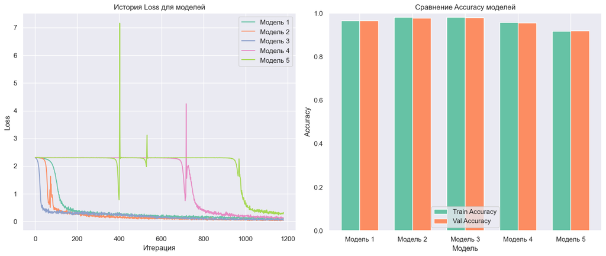

```python
def evaluate_on_loader(model, loader, criterion, device):
    model.eval()
    total_loss = 0
    all_preds = []
    all_labels = []
    total_samples = 0
    with torch.no_grad():
        for images, labels in loader:
            images = images.to(device)
            labels = labels.to(device)
            outputs = model(images)
            loss = criterion(outputs, labels)
            total_loss += loss.item() * images.size(0)
            total_samples += images.size(0)
            preds = outputs.argmax(dim=1)
            all_preds.extend(preds.cpu().numpy())
            all_labels.extend(labels.cpu().numpy())
    avg_loss = total_loss / total_samples
    acc = accuracy_score(all_labels, all_preds)
    return avg_loss, acc

def evaluate_on_data(model, images, labels, criterion, device):
    model.eval()
    images = images.to(device)
    labels = labels.to(device)
    with torch.no_grad():
        outputs = model(images)
        loss = criterion(outputs, labels)
        preds = outputs.argmax(dim=1)
        acc = accuracy_score(labels.cpu().numpy(), preds.cpu().numpy())
    return loss.item(), acc

plt.figure(figsize=(14, 6))

plt.subplot(1, 2, 1)
for idx, model in enumerate(trained_models_list, start=1):
    iterations = range(1, len(model.history) + 1)
    plt.plot(iterations, model.history, label=f"Модель {idx}")
plt.xlabel("Итерация")
plt.ylabel("Loss")
plt.title("История Loss для моделей")
plt.legend()
plt.grid(True)

train_acc_list = []
val_acc_list = []
for model in trained_models_list:
    _, train_acc = evaluate_on_loader(model, mnist_dataloader, criterion, device)
    _, val_acc = evaluate_on_data(model, val_dataset_images, val_dataset.targets, criterion, device)
    train_acc_list.append(train_acc)
    val_acc_list.append(val_acc)

n_models = len(trained_models_list)
indices = np.arange(n_models)
width = 0.35

plt.subplot(1, 2, 2)
plt.bar(indices - width/2, train_acc_list, width, label="Train Accuracy")
plt.bar(indices + width/2, val_acc_list, width, label="Val Accuracy")
plt.xlabel("Модель")
plt.ylabel("Accuracy")
plt.title("Сравнение Accuracy моделей")

plt.xticks(indices, [f"Модель {i}" for i in range(1, n_models + 1)])
plt.ylim([0, 1])
plt.legend()
plt.grid(axis='y')
plt.tight_layout()
plt.show()
```

```python
print(f'Модель {np.argmax(val_acc_list) + 1} показала наилучшее качество: {max(val_acc_list)}')
```

```
Модель 3 показала наилучшее качество: 0.9799
```

Сделайте вывод. Как количество разных слоев влияет на качество и время обучения?

**Вывод по эксперименту 1:**

Как итог имеем: нет зависимости между глубиной нейросети и качеством (более глубокая оказалась хуже), но между глубиной и временем сходимости есть явная связь: чем глубже, тем дольше. Более того, в глубоких сетях будет постепенно затухать градиент. Еще мы видим, что глубокие сети долгое время были на плато, вообще не снижая лосс, при этом показывая странные скачки, которые связаны с особенностями SGD. Если выбрать Adam в качестве оптимизатора, то скачки уйдут, но вот четвертая нейросеть вообще может оставаться на плато значительно бОльшее количество итераций.

**Эксперимент 2.** Теперь выберите лучший вариант, зафиксируйте это количество сверточных и линейных слоев и обучите хотя бы 4 сверточных нейросети, варьируя размеры ядер сверток. Например, в разном порядке поставьте ядра 3x3, 5x5.

```python
conv_count = 5
linear_count = 2
kernel_size_list = [1, 3, 5, 7]
list_of_models = [simple_cnn(
    num_conv_layers=conv_count,
    num_lin_layers=linear_count,
    num_filters=16,
    kernel_size=x,
    padding=1,
    num_classes=10
) for x in kernel_size_list
]
optimizers_list = [optim.SGD(x.parameters(), lr=0.01, momentum=0.9) for x in list_of_models]
```

```python
trained_models_list = [train_model(
    model=list_of_models[i],
    device=device,
    train_loader=mnist_dataloader,
    criterion=criterion,
    optimizer=optimizers_list[i],
    epochs=20
) for i in range(len(list_of_models))]
```

Постройте график лосса и график accuracy, где сравниваются все модели этого эксперимента (на train и на val).

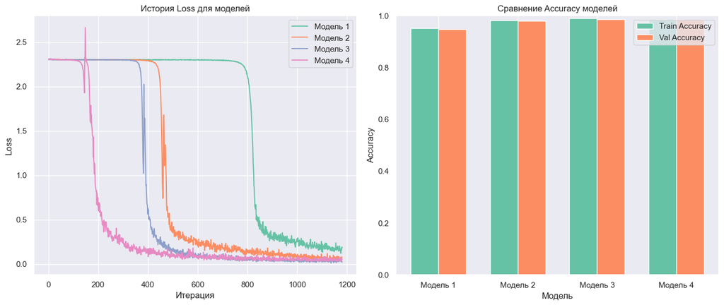

```python
def evaluate_on_loader(model, loader, criterion, device):
    model.eval()
    total_loss = 0
    all_preds = []
    all_labels = []
    total_samples = 0
    with torch.no_grad():
        for images, labels in loader:
            images = images.to(device)
            labels = labels.to(device)
            outputs = model(images)
            loss = criterion(outputs, labels)
            total_loss += loss.item() * images.size(0)
            total_samples += images.size(0)
            preds = outputs.argmax(dim=1)
            all_preds.extend(preds.cpu().numpy())
            all_labels.extend(labels.cpu().numpy())
    avg_loss = total_loss / total_samples
    acc = accuracy_score(all_labels, all_preds)
    return avg_loss, acc

def evaluate_on_data(model, images, labels, criterion, device):
    model.eval()
    images = images.to(device)
    labels = labels.to(device)
    with torch.no_grad():
        outputs = model(images)
        loss = criterion(outputs, labels)
        preds = outputs.argmax(dim=1)
        acc = accuracy_score(labels.cpu().numpy(), preds.cpu().numpy())
    return loss.item(), acc


plt.figure(figsize=(14, 6))

plt.subplot(1, 2, 1)
for idx, model in enumerate(trained_models_list, start=1):
    iterations = range(1, len(model.history) + 1)
    plt.plot(iterations, model.history, label=f"Модель {idx}")
plt.xlabel("Итерация")
plt.ylabel("Loss")
plt.title("История Loss для моделей")
plt.legend()
plt.grid(True)

train_acc_list = []
val_acc_list = []
for model in trained_models_list:
    _, train_acc = evaluate_on_loader(model, mnist_dataloader, criterion, device)
    _, val_acc = evaluate_on_data(model, val_dataset_images, val_dataset.targets, criterion, device)
    train_acc_list.append(train_acc)
    val_acc_list.append(val_acc)

n_models = len(trained_models_list)
indices = np.arange(n_models)
width = 0.35

plt.subplot(1, 2, 2)
plt.bar(indices - width/2, train_acc_list, width, label="Train Accuracy")
plt.bar(indices + width/2, val_acc_list, width, label="Val Accuracy")
plt.xlabel("Модель")
plt.ylabel("Accuracy")
plt.title("Сравнение Accuracy моделей")
plt.xticks(indices, [f"Модель {i}" for i in range(1, n_models + 1)])
plt.ylim([0, 1])
plt.legend()
plt.grid(axis='y')
plt.tight_layout()
plt.show()
```

```python
print(f'Модель с размером ядра {kernel_size_list[np.argmax(val_acc_list)]}x{kernel_size_list[np.argmax(val_acc_list)]} показала наилучшее качество: {max(val_acc_list)}')
```

```
Модель с размером ядра 5x5 показала наилучшее качество: 0.9856
```

Сделайте вывод. Как размеры ядер влияют на качество и время обучения?

**Вывод по эксперименту 2:**

Ситуация типична для гиперпараметра: если слишком маленький, то качество падает, слишком большой — тоже, но вот оптимальный, 5 на 5, позволяет добиться наилучшего качества: 0.986.

**Анализ лучшей модели.** Выберите лучшую конфигурацию из всех по accuracy на валидации. Она должна быть не меньше 97%.

```python
best_model = list_of_models[np.argmax(val_acc_list)]
best_ker_size = kernel_size_list[np.argmax(val_acc_list)]
```

Проведите еще один проход валидации выбранной моделью по всему датасету. В нем посчитайте точность по каждому классу и соберите информацию о неправильных предсказаниях. Равномерна ли точность по отношению к классам? Покажите 10-20 примеров, на которых нейросеть выдала неправильную метку. Что можно о них сказать?

```
Точность по классам:
Класс 0: 99.49% accuracy (Всего 980 примеров)
Класс 1: 99.30% accuracy (Всего 1135 примеров)
Класс 2: 97.29% accuracy (Всего 1032 примеров)
Класс 3: 99.31% accuracy (Всего 1010 примеров)
Класс 4: 99.08% accuracy (Всего 982 примеров)
Класс 5: 98.09% accuracy (Всего 892 примеров)
Класс 6: 98.12% accuracy (Всего 958 примеров)
Класс 7: 99.03% accuracy (Всего 1028 примеров)
Класс 8: 98.77% accuracy (Всего 974 примеров)
Класс 9: 97.03% accuracy (Всего 1009 примеров)
```

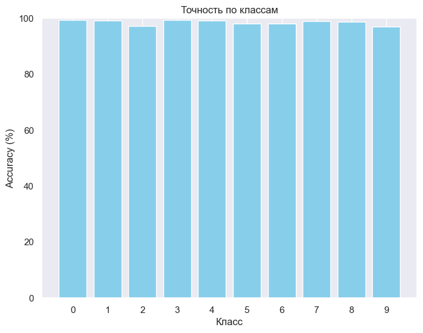

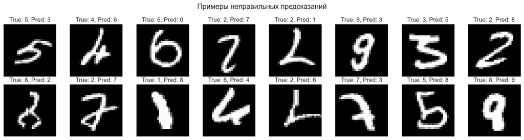

```python
import math
import numpy as np
import matplotlib.pyplot as plt
from sklearn.metrics import accuracy_score

best_model.eval()
with torch.no_grad():
    outputs = best_model(val_dataset_images.to(device))
    preds = outputs.argmax(dim=1).cpu().numpy()
    true_labels = val_dataset.targets.cpu().numpy()

num_classes = 10
class_correct = np.zeros(num_classes)
class_total = np.zeros(num_classes)
misclassified = []

for i in range(len(true_labels)):
    label = true_labels[i]
    pred = preds[i]
    class_total[label] += 1
    if pred == label:
        class_correct[label] += 1
    else:
        misclassified.append((i, val_dataset_images[i].cpu(), label, pred))

per_class_accuracy = class_correct / class_total

print("Точность по классам:")
for c in range(num_classes):
    print(f"Класс {c}: {per_class_accuracy[c]*100:.2f}% accuracy (Всего {int(class_total[c])} примеров)")

plt.figure(figsize=(8, 6))
plt.bar(range(num_classes), per_class_accuracy*100, color='skyblue')
plt.xlabel("Класс")
plt.ylabel("Accuracy (%)")
plt.title("Точность по классам")
plt.xticks(range(num_classes))
plt.ylim([0, 100])
plt.grid(axis='y')
plt.show()

num_examples_to_show = 16
cols = num_examples_to_show // 2

plt.figure(figsize=(15, 4))
for idx, (i, image, true_label, pred_label) in enumerate(misclassified[:num_examples_to_show]):
    plt.subplot(2, cols, idx+1)
    plt.imshow(image.squeeze(), cmap='gray')
    plt.title(f"True: {true_label}, Pred: {pred_label}")
    plt.axis('off')
plt.suptitle("Примеры неправильных предсказаний")
plt.tight_layout()
plt.show()
```

**Ответ:**

**Вывод по всей задаче:**

Сверточные сети могут потребовать подбора гиперпараметров: стоит попробовать комбинировать разные размера ядер сверток. В некоторых ситуациях может быть полезно использовать, как это ни странно, свертку 1х1. Также видно, что при бездумном увеличении числа параметров и количества слоём, качество может не только просто выйти на плато, но и упасть. Ещё можно выделить тот факт, что torch отлично оптимизирован, и изменение количества параметров внутри слоёв не очень сильно замедляет или ускоряет обучение, в то время, как количество слоёв, может влиять на скорость обучение, более существенно (корреляция между скоростью обучения и количеством параметров не является линейной, по крайней мере, в моем локальном случае).

На [первом занятии](https://thetahat.ru/courses/ad/main/1/main_sem_kNN) мы рассматривали классификацию с помощью KNN, который показал высокую точность — 99%. Возникает вопрос: зачем нам изучать более сложные методы, если простой KNN может работать так же хорошо или даже лучше? Но здесь есть обман. В чем он заключается?

*Для ответа на вопрос вспомните, с чем мы работали на первом занятии.*

В KNN мы использовали значительно мЕньшие картинки: если постепенно увеличивать размер изображения, kNN начнет выдавать значительно худшие результаты, а проклятие размерности в метрическом методе покажет себя в полной красе. Плюс, kNN, хоть и не требует обучения, в чистом виде работает достаточно долго (но, собственно, основная причина именно в размерности. Отличия существенны.)

### Задача 2. Визуализиция сверточных слоев

Обучите модель, состоящую как минимум из 4 сверточных слоев, на датасете MNIST. **Количество выходных каналов в каждом сверточном слое должно быть равно 32**, а точность на тестовых данных должна достигать 97%. Для создания модели будет удобно использовать `torch.nn.Sequential`.

```python
conv_model = simple_cnn(
    num_conv_layers=5,
    num_lin_layers=1,
    num_filters=32,
    kernel_size=5,
    padding=1,
    num_classes=10
)
criterion = torch.nn.CrossEntropyLoss()
opt = torch.optim.Adam(conv_model.parameters(), lr=1e-3)

conv_model = train_model(
    model=conv_model,
    device=device,
    train_loader=mnist_dataloader,
    criterion=criterion,
    optimizer=opt,
    epochs=20
)

print(f'Точность: {accuracy_score(val_dataset.targets.cpu().numpy(), conv_model.predict(val_dataset_images).detach().cpu().numpy())}')
```

```
Точность: 0.9905
```

Визуализируйте веса свертки на первом слое. Поскольку веса имеют размерность $(32, 1, K_1, K_2)$, т.к. входное изображение имеет один канал, вам необходимо отобразить 32 изображения (по количеству выходных каналов) фильтрами размера $K_1 \times K_2$.

*Совет.* Здесь и далее серии из 32 картинок визуализируйте в виде сетки с помощью `plt.subplots(4, 8, figsize=...)`. Не забывайте указывать параметр `cmap='gray'`.

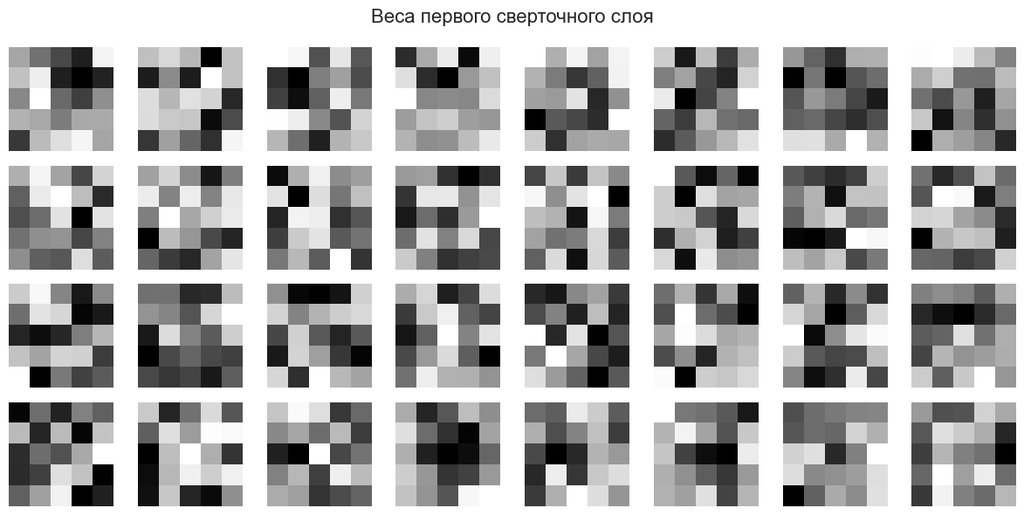

```python
weights = conv_model.conv_layers[0].weight.data.cpu().numpy()

fig, axes = plt.subplots(4, 8, figsize=(12, 6))
fig.suptitle("Веса первого сверточного слоя", fontsize=16)

for i, ax in enumerate(axes.flat):
    if i < weights.shape[0]:
        filter_img = weights[i].squeeze()
        ax.imshow(filter_img, cmap='gray')
    ax.axis('off')

plt.tight_layout()
plt.show()
```

Какую функцию они могут нести? Для ответа на вопрос вспомните фильтры, рассмотренные на семинаре.

Возможно, это похоже на применение оператора Собеля для выделения границ. Первый сверточный слой используется для построения базовых признаковых зависимостей, которые будут использоваться в последующих, более сложных. Примерно это мы и видим.

Для одного произвольного изображения из датасета MNIST визуализируйте выходы **всех слоев** нейросети, включая активацию и пуллинг, вплоть до операции `Flatten`, но не включая её. Каждый выход будет иметь размерность $(32, H_i, W_i)$. Таким образом, для каждого слоя необходимо создать $32$ изображения размером $H_i \times W_i$.

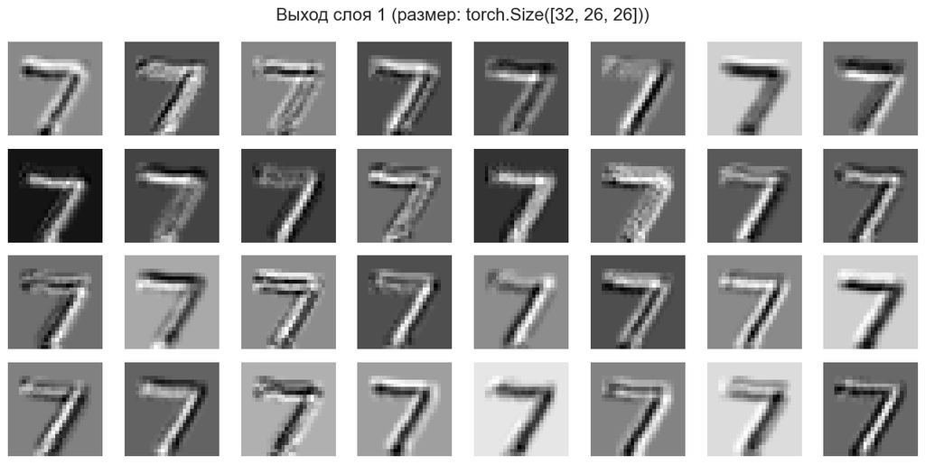

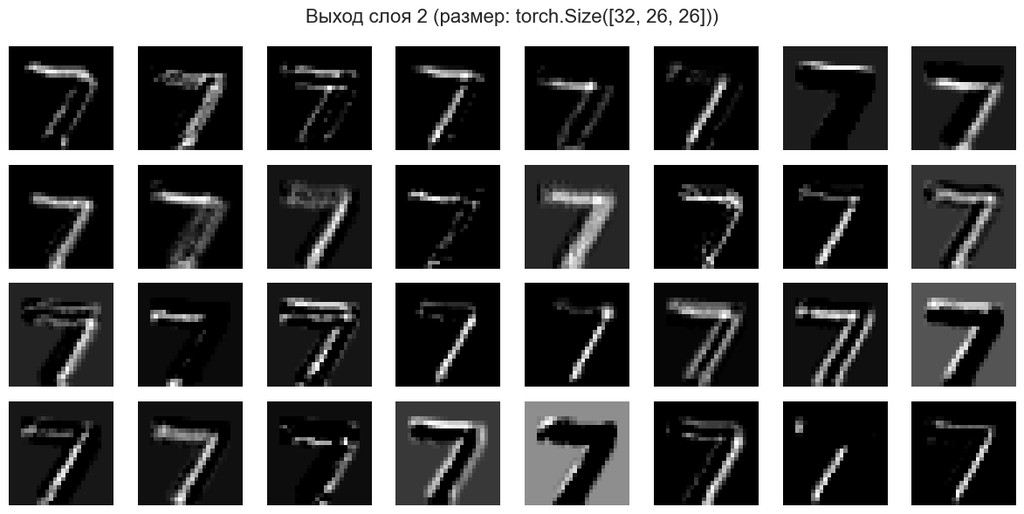

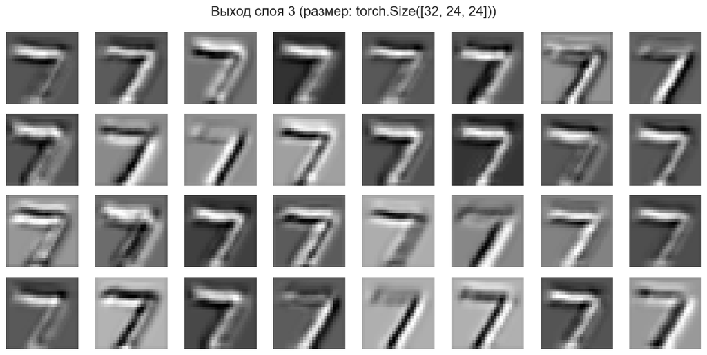

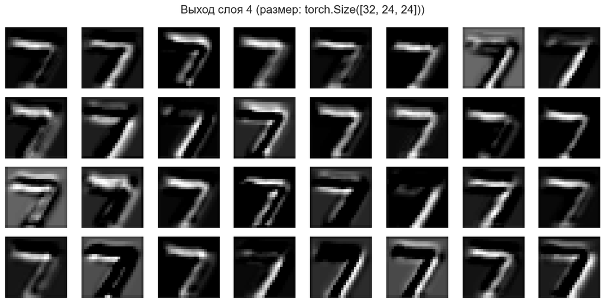

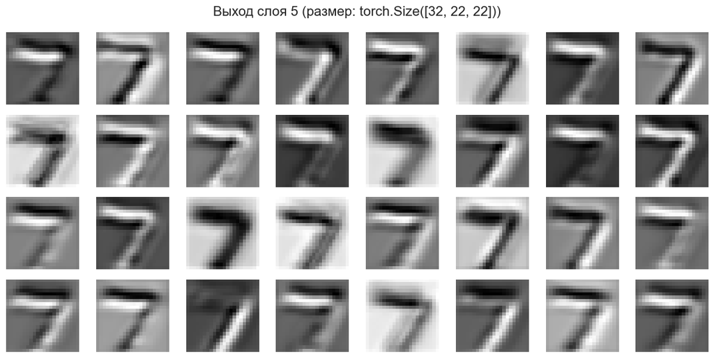

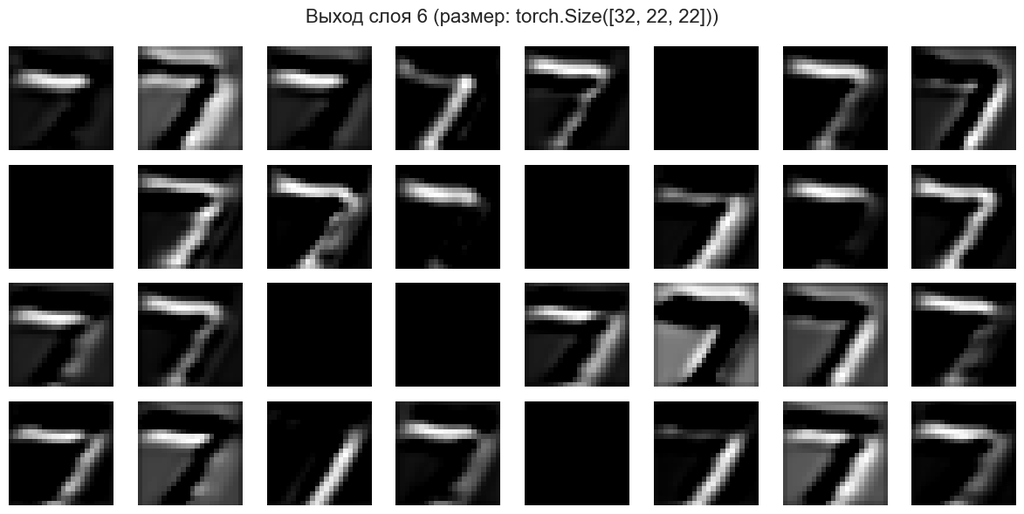

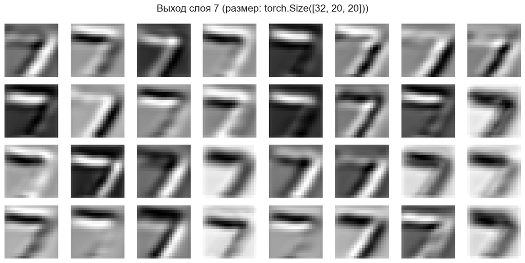

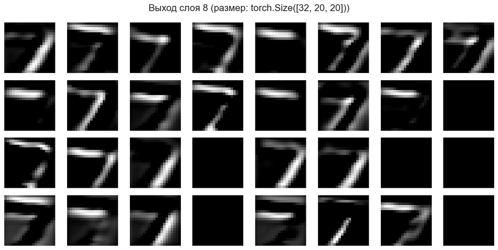

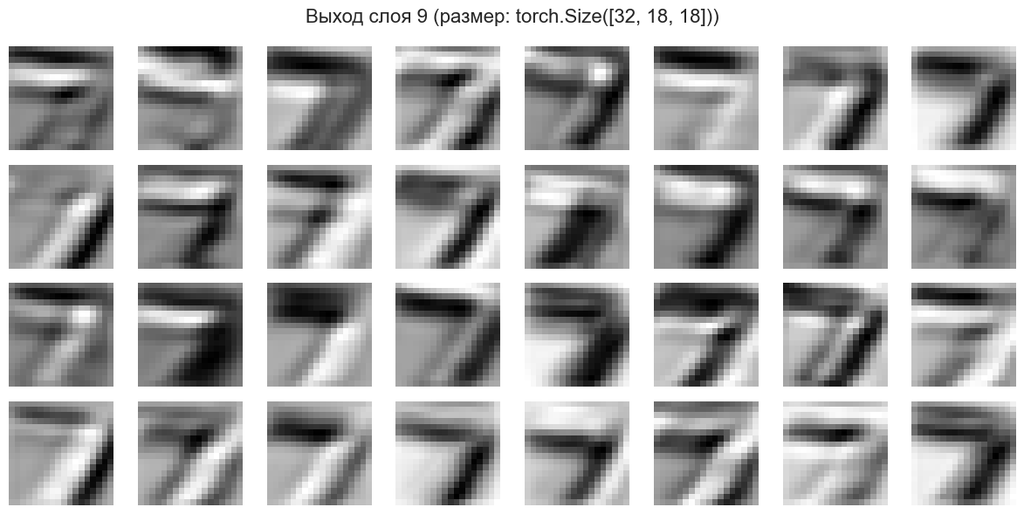

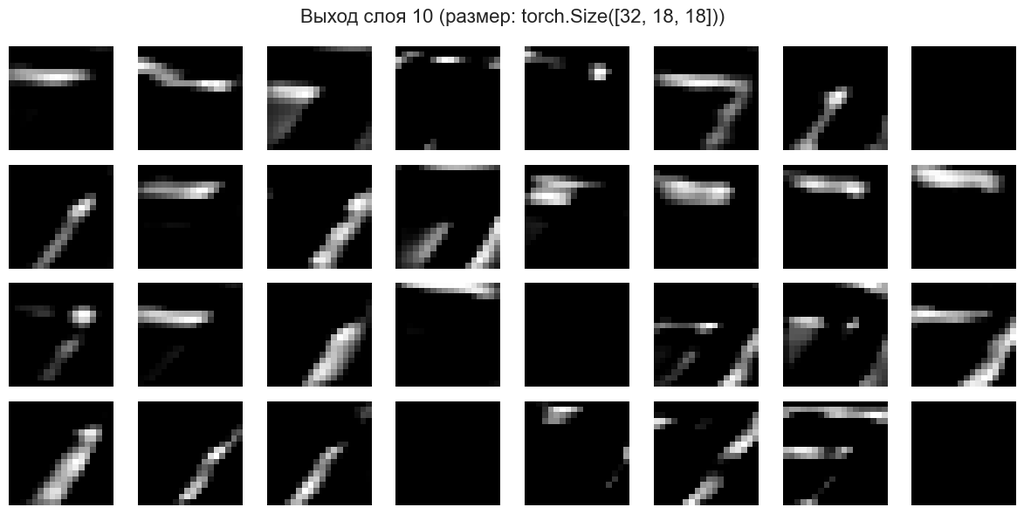

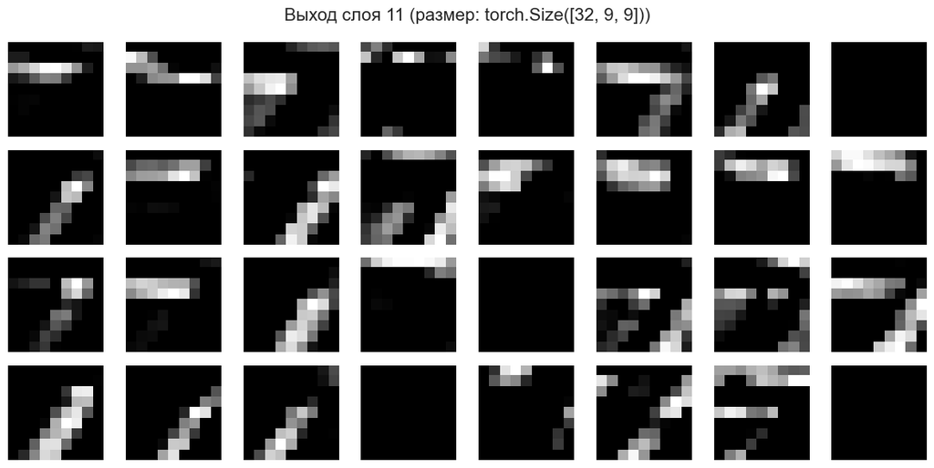

```python
sample_image = val_dataset_images[0].unsqueeze(0)
sample_image = sample_image.to(device)

intermediate_outputs = []

x = sample_image
for idx, layer in enumerate(conv_model.conv_layers):
    x = layer(x)
    intermediate_outputs.append(x.cpu())

x_pool = conv_model.pool(x)
intermediate_outputs.append(x_pool.cpu())

for layer_idx, output in enumerate(intermediate_outputs, start=1):
    feature_maps = output.squeeze(0)
    channels, H, W = feature_maps.shape

    fig, axes = plt.subplots(4, 8, figsize=(12, 6))
    fig.suptitle(f'Выход слоя {layer_idx} (размер: {feature_maps.shape})', fontsize=16)

    for i, ax in enumerate(axes.flat):
        if i < channels:
            ax.imshow(feature_maps[i].detach().numpy(), cmap='gray')
        ax.axis('off')

    plt.tight_layout()
    plt.show()
```

Какие выводы можно сделать о том, как работает ваша сверточная сеть?

Видно, что самая четкая картина видна на первом свёрточном слое: это подтверждает то, что первая свертка выучитывает базовые признаки. В зависимости от фильтра, изображение может меняться: могут быть как негативы, так и наоборот, в результате одной и той же свертки. При этом некоторые фильтры выдавали полностью черные изображения. Вероятно, причина в том, что фильтр не подходит под паттерн на изображении, и не срабатывает на конкретном входе. Это также может быть следствием использования ReLU, и, если бы я использовал tanh/sigmoid + BatchNorm, то подобной ситуации могло и не возникнуть.

Визуализируйте, какие объекты, подаваемые на вход нейросети, в наибольшей степени активируют нейроны в сверточных слоях. Для этого оптимизируйте изображение, чтобы максимизировать выход нейрона.

Ниже представлен шаблон функции, которая находит изображение, максимально усиливающее реакцию нейрона. Пример можно посмотреть в [презентации](https://thetahat.ru/files/ad/main/5/lec5.pdf) с занятия.

```python
def visualize_filter(
        model: nn.Module,
        layer_index: int,
        target_kernel: int,
        learning_rate: float = 1,
        steps: int = 10_000,
        image_size: int = 28,
        device: Union[str, torch.device] = "cpu",
) -> torch.Tensor:
    """
    Визуализирует фильтр сверточного слоя нейронной сети путем оптимизации
    входного изображения, которое максимизирует активацию заданного фильтра.

    Параметры:
        model (nn.Module): Модель нейронной сети, содержащая целевой сверточный слой.
        layer_index (int): Индекс целевого сверточного слоя в модели (по порядку в model.children()).
        target_kernel (int): Индекс фильтра в целевом слое для визуализации.
        learning_rate (float, optional): Скорость обучения для оптимизатора. По умолчанию 1.
        steps (int, optional): Количество шагов оптимизации. По умолчанию 10000.
        image_size (int, optional): Размер стороны квадратного входного изображения. По умолчанию 28.
        device (str|torch.device, optional): Устройство для вычислений ('cpu' или 'cuda'). По умолчанию "cpu".

    Возвращает:
        torch.Tensor: Оптимизированное изображение (тензор формы [1, C, H, W]),
                     которое максимизирует активацию целевого фильтра.
    """
    model.eval().to(device)

    input_img = torch.randn(1, 1, image_size, image_size, requires_grad=True, device=device)

    optimizer = optim.SGD([input_img], lr=learning_rate)

    for step in range(steps):
        optimizer.zero_grad()

        x = input_img
        for idx, layer in enumerate(model.children()):
            x = layer(x)
            if idx == layer_index:
                break
        target_activation = x[0, target_kernel].mean()
        loss = -target_activation

        loss.backward()
        optimizer.step()

        input_img.data = torch.clamp(input_img.data, -1, 1)

        if step % 5000 == 0:
            print(f"Step {step}/{steps}, Loss: {loss.item():.4f}")
    img = (input_img.squeeze().detach().cpu() + 1) / 2
    return img
```

```
Step 0/10000, Loss: -0.9507
Step 5000/10000, Loss: -6.7324
```

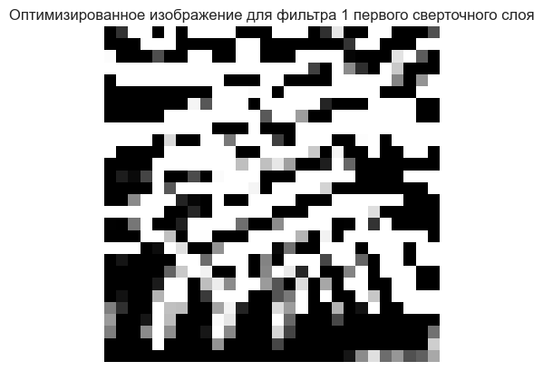

```
Step 0/10000, Loss: -0.0426
Step 5000/10000, Loss: -30.4164
```

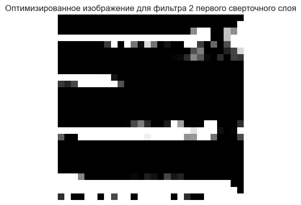

```
Step 0/10000, Loss: -1.5430
Step 5000/10000, Loss: -21.0510
```

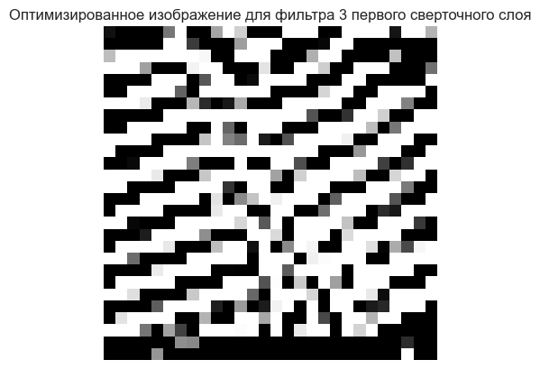

```
Step 0/10000, Loss: -1.2013
Step 5000/10000, Loss: -14.3482
```

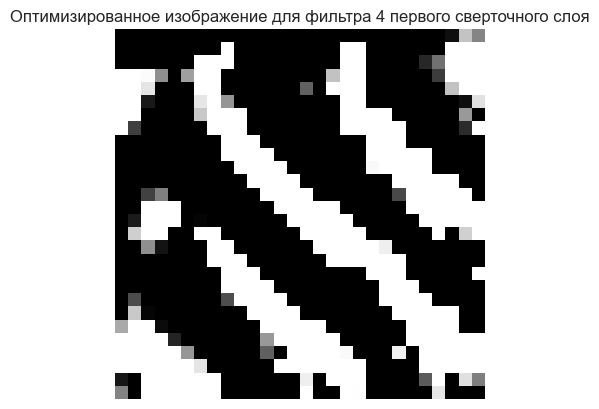

```
Step 0/10000, Loss: -0.6575
Step 5000/10000, Loss: -11.3916
```

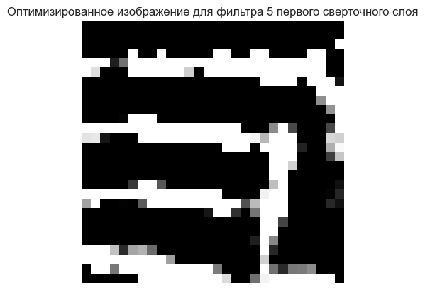

```python
for x in range(1, 6):
    optimized_img = visualize_filter(model=conv_model, layer_index=0, target_kernel=x, learning_rate=1, steps=10000, image_size=28, device='cuda')
    plt.imshow(optimized_img.squeeze(), cmap='gray')
    plt.title(f"Оптимизированное изображение для фильтра {x} первого сверточного слоя")
    plt.axis('off')
    plt.show()
```

Сделайте выводы о том, как с глубиной слоя меняется способность нейрона видеть различные паттерны на изображении.

### Задача 3. Перенос стиля

*Данную задачу, возможно, проще сделать в Google Colab.*

В данной задаче вы потренируетесь в работе с картинками и составлением промптов. Используя код с [семинара](https://thetahat.ru/files/ad/main/5/cv_complex_examples), проведите перенос стиля на хотя бы 3 своих примерах.

> Заметьте, что в примерах с семинара в качестве картинок стиля и контента использовались картинки среднего разрешения. Если возникают проблемы, например:
> - оптимизация останавливается на 0-й эпохе и не создает картинку;
> - loss в какой-то момент стал nan;
> - нехватка RAM;

> то либо уменьшите разрешение ваших картинок, либо попробуйте картинку полегче.

```python
file_path = "NST.py"
# %cd Neural-Style-Transfer
with open(file_path, "r") as file:
    lines = file.readlines()[:183]
from NST import *
```

[output not shown]

[output cut: 980 more lines]

[output not shown]

```python
import os
import seaborn as sns
from pathlib import Path
import matplotlib.pyplot as plt
def run_neural_style_transfer(content_image="c1.jpg", style_image="s1.jpg"):
    """
    Функция для запуска метода Neural Style Transfer.

    :param content_image: имя файла картинки контента
    :param style_image: имя файла картинки стиля
    :return: results_path -- путь к папке, в которую сохранился результат
    """
    PATH = ""
    default_resource_dir = os.path.join(PATH, "data")
    content_images_dir = os.path.join(default_resource_dir, "content-images")
    style_images_dir = os.path.join(default_resource_dir, "style-images")
    output_img_dir = os.path.join(default_resource_dir, "output-images")
    img_format = (4, ".jpg")

    # Задаем конфиги, включая вес компонент лосса
    optimization_config = {
        "content_img_name": content_image,
        "style_img_name": style_image,
        "height": 400,
        "content_weight": 100000.0,
        "style_weight": 30000.0,
        "tv_weight": 1.0,
    }
    optimization_config["content_images_dir"] = content_images_dir
    optimization_config["style_images_dir"] = style_images_dir
    optimization_config["output_img_dir"] = output_img_dir
    optimization_config["img_format"] = img_format

    results_path = neural_style_transfer(optimization_config)
    return results_path

def visualize_style_transfer(content_image, style_image, results_path):
    """
    Визуализация результатов.

    :param content_image: имя файла картинки контента
    :param style_image: имя файла картинки стиля
    :param results_path: путь к папке, в которую сохранился результат
    """
    if len(os.listdir(results_path)) == 0:
        return
    plt.figure(figsize=(13, 3))
    folders = [
        "content-images/",
        "output-images/" + Path(results_path).name + "/",
        "style-images/",
    ]
    combined_image = (
            Path(content_image).stem + "_" + Path(style_image).stem + ".jpg"
    )
    files = [content_image, combined_image, style_image]
    titles = ["Контент", "Результат", "Стиль"]
    for i in range(3):
        plt.subplot(1, 3, i + 1)
        plt.imshow(plt.imread("data/" + folders[i] + files[i]))
        plt.title(titles[i])
        plt.xticks([])
        plt.yticks([])
```

```python
content_images = sorted(os.listdir("data/content-images"))
style_images = sorted(os.listdir("data/style-images"))

result_paths = []
for content_image, style_image in zip(content_images, style_images):
    results_path = run_neural_style_transfer(content_image, style_image)
    result_paths.append(results_path)
```

[output not shown]

[output cut: 2994 more lines]

[output not shown]

Теперь для каждой пары контекст-стиль попытайтесь сгенерировать картинку с таким контекстом и стилем с помощью диффузионной модели, рассмотренной на семинаре, задав нужный промпт.

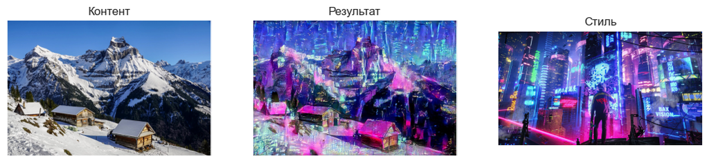

[figure not shown]

[figure not shown]

```python
for content_image, style_image, results_path in zip(
        content_images, style_images, result_paths
):
    visualize_style_transfer(content_image, style_image, results_path)
```

**Вывод:**

Модель переносит стель на объект, в случае, если стиль подобран корректно (и действительно является стилем), то модель, не изменяя контента, и не добавляя того, что было на стиле, переносит стиль на контент. Но, если стиль по сути может являться в том числе и контентом, то в результат может просочиться частичка объектов, которые были на стиле (например, можно в третьем случае разглядеть, что вокруг флага США выделяются очертания головы или кепки).